# Cyclistic Bike-Share

How annual members and casual riders use bikes differently

Eduardo Escudero

## Cyclistic Bike-Share

**Casual riders behave more like leisure users. Members behave more like routine users.**

Executive snapshot

Ride length

16.72 min

Casual average trip length versus **11.38 min** for members.

Weekend weight

37.2%

Weekend share for casual riders versus **23.4%** for members.

Seasonality

13.9x

Casual peak-to-trough monthly swing versus **4x** for members.

This deck keeps the structure flat and linear to avoid navigation issues while still adding more visual polish.

## Agenda

Business question Data scope Ride length Weekday mix Time of day Monthly pattern Recommendations

**Presentation logic:** start with the cleaned data, then compare trip duration, weekly timing, hourly timing, and monthly demand.

## Business question

**How do annual members and casual riders use Cyclistic bikes differently?**

- Members are more profitable than casual riders.
- Marketing needs evidence on when, how, and how long each group rides.
- The business goal is to identify where casual behavior looks most convertible into membership.

**Takeaway:** the analysis focuses on behavioral differences that can support membership conversion strategy.

## Data scope and filtering

Monthly files

12

Trip-level historical data for 2025.

Trips loaded

5,552,994

Raw observations before filtering.

Trips kept

5,519,692

Cleaned sample used in the analysis.

Trips removed

0.6%

Invalid or extreme observations excluded.

Filtering rules: - Remove non-positive duration. - Remove trips with missing end coordinates. - Remove rides above the 99.5th percentile of duration.

**Takeaway:** findings are based on a cleaned sample of plausible rides, not on raw operational logs.

## Why this comparison matters

Casual riders

Longer trips, heavier weekend usage, stronger seasonal spikes.

Members

Shorter trips, more weekday concentration, steadier demand over time.

Implication

Conversion messaging should emphasize convenience, routine value, and repeated use.

**Takeaway:** the strongest evidence points to different trip purposes, not just different ride volumes.

## Key finding 1: casual riders take longer trips

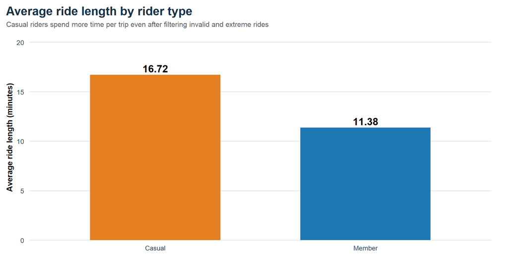

**Takeaway:** casual riders spend more time per trip, consistent with more leisure-oriented usage.

## Key finding 2: the weekday mix is different

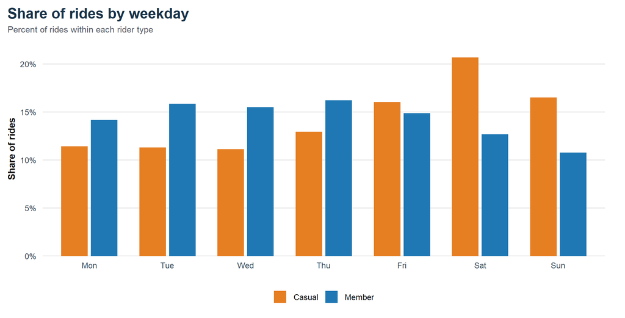

**Takeaway:** casual riders are more concentrated on weekends, while members show a stronger weekday profile.

## Key finding 2b: casual riders also ride longer on weekends

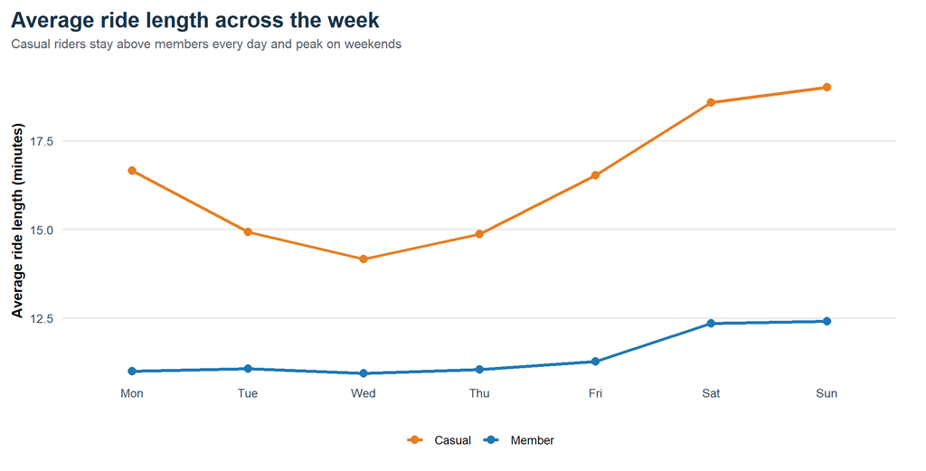

**Takeaway:** the difference is not only when each group rides, but also how they ride across the week.

## Key finding 3: time of day separates the groups

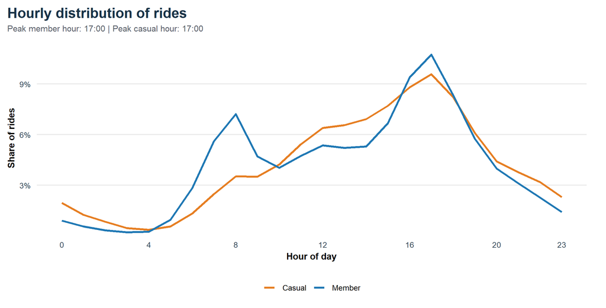

**Takeaway:** members look more routine-oriented, while casual riders appear more tied to free time than fixed commuting windows.

## Key finding 4: both groups are seasonal, but not equally

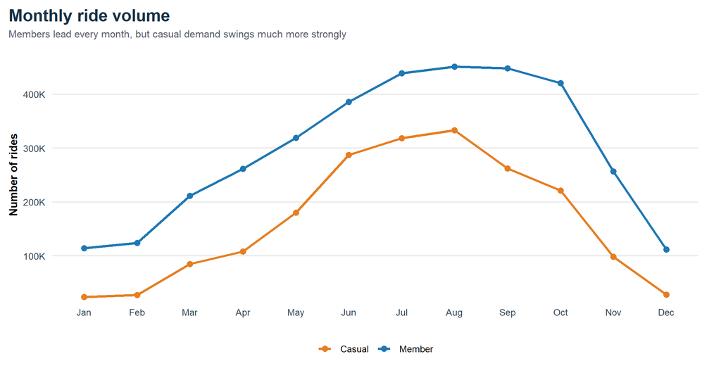

- Both groups rise from spring into summer and decline in winter.
- Casual riders swing about **13.9x** from January to August.
- Members also vary seasonally, but less sharply: about **4x**.
- The casual/member ratio rises from **0.21** in January to **0.74** in August.

**Takeaway:** seasonality affects both groups, but it amplifies casual demand much more strongly.

## Recommendations

1. Convert weekend casuals

Focus membership offers on high-leisure periods, especially Saturday and Sunday trips.

2. Sell convenience and routine

Message membership as a better fit for repeated, shorter, more frequent usage.

3. Time campaigns with demand peaks

Prioritize months and hours when casual demand accelerates and repeat behavior is more likely.

**Takeaway:** the best conversion opportunities appear where casual demand is high, recurring, and seasonally amplified.

## Bottom line

**Casual riders look more leisure-oriented. Members look more routine-oriented.**

The strongest differences are visible in: - trip duration - weekday distribution - time-of-day behavior - the strength of seasonal demand

This version keeps the slide structure flat on purpose. If it renders cleanly, the next risky feature to test would be a multi-column content slide.